# Driver Genes PAAD

# dndscv

## Objective

Identify driver genes in dataset of PAAD (Pancreatic Adenocarcinoma) from TCGA consortium.

## Preparation

```bash
cd /mnt/data/bioinfo-estadistica-2/lgonzalez/datos_dani/cancer_genomics/data/PAAD

# Copy the BLCA example to personal computer
scp -r ysosa@ken.lavis.unam.mx:/mnt/data/bioinfo-estadistica-2/lgonzalez/datos_dani/cancer_genomics/data/PAAD .
```

## Data loading and exploration

To visualize the data with dndscv, we need an input file of 5 columns, which we can extract from MAF files or VCF files:

1. Sample ID
2. Chromosome
3. Position
4. Reference
5. Mutation

The info is in `muts`

```
# Load library
library(dndscv)

# Read the file with 5 columns of bladder cancer
file_mutations = read.table("C:/Users/Dell/Documents/funcional2/PAAD/data_mutations.txt", header=T, sep='\t', stringsAsFactors=F)
```

```
head(file_mutations)
```

|  | Hugo_Symbol | Entrez_Gene_Id | Center | NCBI_Build | Chromosome | Start_Position | End_Position | Strand | Consequence | Variant_Classification | Variant_Type | Reference_Allele | Tumor_Seq_Allele1 | Tumor_Seq_Allele2 | dbSNP_RS | dbSNP_Val_Status | Tumor_Sample_Barcode | Matched_Norm_Sample_Barcode | Match_Norm_Seq_Allele1 | Match_Norm_Seq_Allele2 | Tumor_Validation_Allele1 | Tumor_Validation_Allele2 | Match_Norm_Validation_Allele1 | Match_Norm_Validation_Allele2 | Verification_Status | Validation_Status | Mutation_Status | Sequencing_Phase | Sequence_Source | … |
| --- | --- | --- | --- | --- | --- | --- | --- | --- | --- | --- | --- | --- | --- | --- | --- | --- | --- | --- | --- | --- | --- | --- | --- | --- | --- | --- | --- | --- | --- | --- |
| 1 | WDR37 | 22884 | . | GRCh37 | 10 | 1149626 | 1149626 | + | missense_variant | Missense_Mutation | SNP | C | C | A | rs150728900 | . | TCGA-2J-AAB1-01 | TCGA-2J-AAB1-10 | C | C | . | . | . | . | . | . | . | . | . | … |
| 2 | NEBL | 10529 | . | GRCh37 | 10 | 21098813 | 21098813 | + | missense_variant | Missense_Mutation | SNP | G | G | A | rs776914197 | . | TCGA-2J-AAB1-01 | TCGA-2J-AAB1-10 | G | G | . | . | . | . | . | . | . | . | . | … |
| 3 | ANKRD26 | 22852 | . | GRCh37 | 10 | 27324564 | 27324565 | + | frameshift_variant | Frame_Shift_Ins | INS | - | - | T | novel | . | TCGA-2J-AAB1-01 | TCGA-2J-AAB1-10 | - | - | . | . | . | . | . | . | . | . | . | … |
| 4 | EXPH5 | 23086 | . | GRCh37 | 11 | 108382677 | 108382678 | + | frameshift_variant | Frame_Shift_Ins | INS | - | - | G | novel | . | TCGA-2J-AAB1-01 | TCGA-2J-AAB1-10 | - | - | . | . | . | . | . | . | . | . | . | … |
| 5 | MUC5AC | 4586 | . | GRCh37 | 11 | 1213464 | 1213465 | + | non_coding_transcript_exon_variant | RNA | INS | - | - | G | novel | . | TCGA-2J-AAB1-01 | TCGA-2J-AAB1-10 | - | - | . | . | . | . | . | . | . | . | . | … |
| 6 | UBASH3B | 84959 | . | GRCh37 | 11 | 122659916 | 122659916 | + | missense_variant | Missense_Mutation | SNP | G | G | A | novel | . | TCGA-2J-AAB1-01 | TCGA-2J-AAB1-10 | G | G | . | . | . | . | . | . | . | . | . | … |

```
#First observations of dataset
muts = file_mutations[ , c("Tumor_Sample_Barcode", "Chromosome", "Start_Position", "Reference_Allele", "Tumor_Seq_Allele2")]
colnames(muts) = c("sampleID", "chr", "pos", "ref", "mut")
head(muts)
```

|  | sampleID | chr | pos | ref | mut |
| --- | --- | --- | --- | --- | --- |
| 1 | TCGA-2J-AAB1-01 | 10 | 1149626 | C | A |
| 2 | TCGA-2J-AAB1-01 | 10 | 21098813 | G | A |
| 3 | TCGA-2J-AAB1-01 | 10 | 27324564 | - | T |
| 4 | TCGA-2J-AAB1-01 | 11 | 108382677 | - | G |
| 5 | TCGA-2J-AAB1-01 | 11 | 1213464 | - | G |
| 6 | TCGA-2J-AAB1-01 | 11 | 122659916 | G | A |

```
clinical_data = read.table("C:/Users/Dell/Documents/funcional2/PAAD/paad_tcga_pan_can_atlas_2018_clinical_data.tsv", header=T, sep='\t', stringsAsFactors=F)
head(clinical_data)
```

|  | Study.ID | Patient.ID | Sample.ID | Diagnosis.Age | Neoplasm.Disease.Stage.American.Joint.Committee.on.Cancer.Code | American.Joint.Committee.on.Cancer.Publication.Version.Type | Aneuploidy.Score | Buffa.Hypoxia.Score | Cancer.Type | TCGA.PanCanAtlas.Cancer.Type.Acronym | Cancer.Type.Detailed | Last.Communication.Contact.from.Initial.Pathologic.Diagnosis.Date | Birth.from.Initial.Pathologic.Diagnosis.Date | Last.Alive.Less.Initial.Pathologic.Diagnosis.Date.Calculated.Day.Value | Disease.Free..Months. | Disease.Free.Status | Months.of.disease.specific.survival | Disease.specific.Survival.status | Ethnicity.Category | Form.completion.date | Fraction.Genome.Altered | Genetic.Ancestry.Label | Neoplasm.Histologic.Grade | Neoadjuvant.Therapy.Type.Administered.Prior.To.Resection.Text | ICD.10.Classification | International.Classification.of.Diseases.for.Oncology..Third.Edition.ICD.O.3.Histology.Code | International.Classification.of.Diseases.for.Oncology..Third.Edition.ICD.O.3.Site.Code | Informed.consent.verified | In.PanCan.Pathway.Analysis | … |
| --- | --- | --- | --- | --- | --- | --- | --- | --- | --- | --- | --- | --- | --- | --- | --- | --- | --- | --- | --- | --- | --- | --- | --- | --- | --- | --- | --- | --- | --- | --- |
| 1 | paad_tcga_pan_can_atlas_2018 | TCGA-2J-AAB1 | TCGA-2J-AAB1-01 | 65 | STAGE IIB | 7TH | 2 | -25 | Pancreatic Cancer | PAAD | Pancreatic Adenocarcinoma | NA | -23962 | 0 | 2.169839 | 0:DiseaseFree | 2.169839 | 1:DEAD WITH TUMOR | NA | 7/16/14 | 0.0697 | EUR | G3 | No | C25.0 | 8480/3 | C25.0 | Yes | Yes | … |
| 2 | paad_tcga_pan_can_atlas_2018 | TCGA-2J-AAB4 | TCGA-2J-AAB4-01 | 48 | STAGE IIB | 7TH | 6 | 1 | Pancreatic Cancer | PAAD | Pancreatic Adenocarcinoma | 729 | -17794 | 0 | 23.966861 | 0:DiseaseFree | 23.966861 | 0:ALIVE OR DEAD TUMOR FREE | NA | 7/16/14 | 0.1518 | EUR | G2 | No | C25.8 | 8140/3 | C25.8 | Yes | Yes | … |
| 3 | paad_tcga_pan_can_atlas_2018 | TCGA-2J-AAB6 | TCGA-2J-AAB6-01 | 75 | STAGE IIA | 7TH | 13 | 23 | Pancreatic Cancer | PAAD | Pancreatic Adenocarcinoma | NA | -27600 | 0 | NA | NA | 9.632771 | 1:DEAD WITH TUMOR | NA | 7/16/14 | 0.3743 | EUR | G2 | No | C25.1 | 8500/3 | C25.1 | Yes | Yes | … |
| 4 | paad_tcga_pan_can_atlas_2018 | TCGA-2J-AAB8 | TCGA-2J-AAB8-01 | 71 | STAGE IIB | 7TH | 9 | -23 | Pancreatic Cancer | PAAD | Pancreatic Adenocarcinoma | 80 | -26028 | 0 | NA | NA | 2.630108 | 0:ALIVE OR DEAD TUMOR FREE | NA | 7/16/14 | 0.0662 | EUR | G3 | No | C25.0 | 8500/3 | C25.0 | Yes | Yes | … |
| 5 | paad_tcga_pan_can_atlas_2018 | TCGA-2J-AAB9 | TCGA-2J-AAB9-01 | 70 | STAGE IIB | 7TH | 0 | -27 | Pancreatic Cancer | PAAD | Pancreatic Adenocarcinoma | NA | -25920 | 0 | 17.128579 | 1:Recurred/Progressed | 20.613473 | 1:DEAD WITH TUMOR | NA | 7/16/14 | 0.0043 | EUR | G1 | No | C25.0 | 8500/3 | C25.0 | Yes | Yes | … |
| 6 | paad_tcga_pan_can_atlas_2018 | TCGA-2J-AABA | TCGA-2J-AABA-01 | 55 | STAGE IIB | 7TH | 6 | -31 | Pancreatic Cancer | PAAD | Pancreatic Adenocarcinoma | NA | -20133 | 0 | NA | NA | 19.955946 | 1:DEAD WITH TUMOR | NA | 7/16/14 | 0.0977 | EUR | G2 | No | C25.0 | 8500/3 | C25.0 | Yes | Yes | … |

Exploring the data base structure

```
# Number of samples
cat("Number of samples: ", length(unique(muts$sampleID)), "\n")
```

```
Number of samples:  165
```

```
# Number of mutations
cat("Number of mutations: ", nrow(muts), "\n")
```

```
Number of mutations:  15576
```

Mutational burden per sample

```
barplot(sort(table(muts$sampleID)), ylab="Number of mutations", xlab="Donors", las=2, names.arg="", main="Mutational Burden")
```

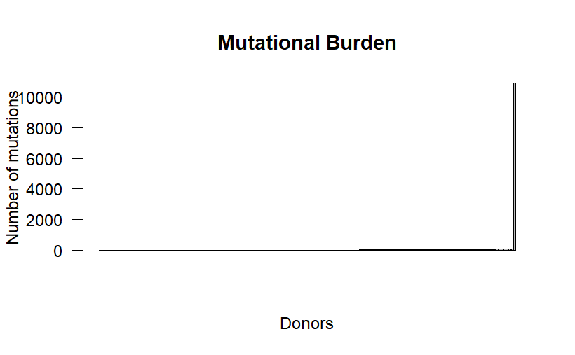

It’s important to exclude the **hypermutators** (more than 500 mutations in the exome) because it can have a negative impact on the statistical process to detect drivers.

```
# Verifica exactamente cuántas muestras caen en cada rango
mut_count = table(muts$sampleID)

sum(mut_count > 1000)   # hipermutadores extremos
```

```
[1] 1
```

```
sum(mut_count > 500)    # hipermutadores moderados
```

```
[1] 1
```

```
sum(mut_count > 200)    # zona gris
```

```
[1] 1
```

```
# Ver el outlier
sort(mut_count, decreasing = TRUE)[1:5]
```

```
TCGA-IB-7651-01 TCGA-FB-AAPP-01 TCGA-3A-A9I9-01 TCGA-HZ-A9TJ-01 TCGA-HZ-7918-01
          10927             113             110             110             101
```

There’s only one hypermutator with over 10,927 mutations.

## Driver detection

### Gene level signals of selection

To detect driver genes, we must remove hypermutators (`max_coding_muts_per_sample=500`) and samples with more than 3 mutation in a given gene (`max_muts_per_gene_per_sample=3`).

The `outmats=T` option generates matrixes with information about the mutation in the trinucleotide context, type of substitution and specific site.

```
dout = dndscv(muts, max_muts_per_gene_per_sample=3,max_coding_muts_per_sample=500, outmats=T)
```

```
[1] Loading the environment...
[2] Annotating the mutations...
Aviso en dndscv(muts, max_muts_per_gene_per_sample = 3, max_coding_muts_per_sample = 500,  :
  Mutations observed in contiguous sites within a sample. Please annotate or remove dinucleotide or complex substitutions for best results.
Aviso en dndscv(muts, max_muts_per_gene_per_sample = 3, max_coding_muts_per_sample = 500,  :
  Same mutations observed in different sampleIDs. Please verify that these are independent events and remove duplicates otherwise.
    Note: 1 samples excluded for exceeding the limit of mutations per sample (see the max_coding_muts_per_sample argument in dndscv). 139 samples left after filtering.
    Note: 7 mutations removed for exceeding the limit of mutations per gene per sample (see the max_muts_per_gene_per_sample argument in dndscv)
Aviso en dndscv(muts, max_muts_per_gene_per_sample = 3, max_coding_muts_per_sample = 500,  :
  17 (0.44%) mutations have a wrong reference base (see the affected mutations in dndsout$wrongmuts). Please identify the causes and rerun dNdScv.
[3] Estimating global rates...
[4] Running dNdSloc...
[5] Running dNdScv...
    Regression model for substitutions (theta = 3.92).
Aviso en theta.ml(Y, mu, sum(w), w, limit = control$maxit, trace = control$trace >  :
  iteration limit reached
Aviso en theta.ml(Y, mu, sum(w), w, limit = control$maxit, trace = control$trace >  :
  iteration limit reached
    Regression model for indels (theta = 8.49)
```

The output lists only unique mutations if the samples are related. Some bases were affected but we’ll ignore it because it’s a very small number

### Looking at the output

```
names(dout)
```

```
 [1] "globaldnds"   "sel_cv"       "sel_loc"      "annotmuts"    "genemuts"     "geneindels"   "mle_submodel" "exclsamples"
 [9] "exclmuts"     "nbreg"        "nbregind"     "poissmodel"   "wrongmuts"    "syncv"        "N"            "L"
```

## Table of significant genes

Analyze genes with significant q-values (combined p-value for the different p-values calculated), which are stored in `sel_cv$qglobal_cv`

```
driver_genes = dout$sel_cv[which(dout$sel_cv$qglobal_cv < 0.1), ]
driver_genes
```

|  | gene_name | n_syn | n_mis | n_non | n_spl | n_ind | wmis_cv | wnon_cv | wspl_cv | wind_cv | pmis_cv | ptrunc_cv | pallsubs_cv | pind_cv | qmis_cv | qtrunc_cv | qallsubs_cv | qind_cv | pglobal_cv | qglobal_cv |
| --- | --- | --- | --- | --- | --- | --- | --- | --- | --- | --- | --- | --- | --- | --- | --- | --- | --- | --- | --- | --- |
| 18057 | TP53 | 0 | 39 | 5 | 4 | 7 | 617.37425 | 1419.13994 | 1419.13994 | 1377.3436 | 0.000000e+00 | 0.000000e+00 | 0.000000e+00 | 1.286202e-19 | 0.000000e+00 | 0.000000e+00 | 0.000000e+00 | 1.292054e-15 | 0.000000e+00 | 0.000000e+00 |
| 9225 | KRAS | 2 | 58 | 0 | 0 | 0 | 2238.53475 | 0.00000 | 0.00000 | 0.0000 | 0.000000e+00 | 9.359000e-01 | 0.000000e+00 | 1.000000e+00 | 0.000000e+00 | 9.871040e-01 | 0.000000e+00 | 1.000000e+00 | 0.000000e+00 | 0.000000e+00 |
| 3523 | CDKN2A.p16INK4a | 1 | 6 | 8 | 0 | 7 | 70.59375 | 2203.22483 | 2203.22483 | 3456.5184 | 8.829227e-09 | 0.000000e+00 | 0.000000e+00 | 2.061826e-22 | 4.434700e-05 | 0.000000e+00 | 0.000000e+00 | 4.142415e-18 | 0.000000e+00 | 0.000000e+00 |
| 3522 | CDKN2A.p14arf | 0 | 10 | 0 | 0 | 4 | 171.70231 | 0.00000 | 0.00000 | 2331.5720 | 7.771561e-16 | 9.279565e-01 | 7.660539e-15 | 6.734424e-13 | 5.204615e-12 | 9.871040e-01 | 3.847697e-11 | 3.382533e-09 | 0.000000e+00 | 0.000000e+00 |
| 16238 | SMAD4 | 0 | 2 | 5 | 0 | 6 | 37.97412 | 884.51811 | 884.51811 | 841.1367 | 1.958047e-03 | 5.356826e-13 | 1.963985e-13 | 7.915501e-16 | 9.243516e-01 | 3.587466e-09 | 7.891683e-10 | 5.301011e-12 | 0.000000e+00 | 0.000000e+00 |
| 14680 | RNF43 | 0 | 3 | 0 | 1 | 3 | 22.70894 | 75.49003 | 75.49003 | 296.6509 | 9.667790e-04 | 1.157946e-02 | 3.172712e-04 | 2.356693e-07 | 8.976447e-01 | 9.871040e-01 | 4.687745e-01 | 9.469663e-04 | 1.818178e-09 | 6.088168e-06 |
| 1465 | ARID1A | 0 | 0 | 2 | 1 | 2 | 0.00000 | 213.58439 | 213.58439 | 67.8257 | 5.432480e-01 | 1.030463e-06 | 4.513984e-06 | 4.743513e-04 | 9.243516e-01 | 5.175758e-03 | 1.511507e-02 | 1.000000e+00 | 4.488390e-08 | 1.288232e-04 |

```
genes = driver_genes$gene_name
```

There are 7 significative genes: *TP53*, *KRAS*, *CDKN2A.p16INK4a*, *CDKN2A.p14arf,* *SMAD4, RNF43, ARID1A*

```
options(scipen = 999)
dout$sel_cv[which(dout$sel_cv$qglobal_cv < 0.1 & # Verifies it's significant
                    (dout$sel_cv$wnon_cv < 1 |
                    dout$sel_cv$wspl_cv < 1 |
                    dout$sel_cv$wind_cv < 1)), ]
```

|  | gene_name | n_syn | n_mis | n_non | n_spl | n_ind | wmis_cv | wnon_cv | wspl_cv | wind_cv | pmis_cv | ptrunc_cv | pallsubs_cv | pind_cv | qmis_cv | qtrunc_cv | qallsubs_cv | qind_cv | pglobal_cv | qglobal_cv |
| --- | --- | --- | --- | --- | --- | --- | --- | --- | --- | --- | --- | --- | --- | --- | --- | --- | --- | --- | --- | --- |
| 9225 | KRAS | 2 | 58 | 0 | 0 | 0 | 2238.5347 | 0 | 0 | 0.000 | 0.000000e+00 | 0.9359000 | 0.000000e+00 | 1.000000e+00 | 0.000000e+00 | 0.987104 | 0.000000e+00 | 1.000000e+00 | 0 | 0 |
| 3522 | CDKN2A.p14arf | 0 | 10 | 0 | 0 | 4 | 171.7023 | 0 | 0 | 2331.572 | 7.771561e-16 | 0.9279565 | 7.660539e-15 | 6.734424e-13 | 5.204615e-12 | 0.987104 | 3.847697e-11 | 3.382533e-09 | 0 | 0 |

```
geneci(dout, gene_list = "TP53")
```

```
Calculating CI95 across all genes...
```

| gene | mis_mle | tru_mle | mis_low | tru_low | mis_high | tru_high |
| --- | --- | --- | --- | --- | --- | --- |
| TP53 | 617.3742 | 1419.14 | 221.6157 | 419.4502 | 2615.553 | 6540.783 |

## Hotspots

```
for (gene in genes){
  name_gene = dout$annotmuts[which(dout$annotmuts$gene == gene), ]
  cat("Table of gene: ", gene, "\n")
  print(table(name_gene$aachange))
  cat("\n")
}
```

```
Table of gene:  TP53

    . C238Y E298* G154V G245D G245S G266E H179R H214R I255T L194H M246R N131I P151T P152L P250L P278S Q192*  Q38* R110L R175H
   11     1     1     1     1     1     1     1     1     1     1     1     1     1     1     1     1     1     1     1     1
R196* R213* R248L R248Q R248W R273C R273H R282G R282W R337C S215G S241F S241Y V173L V197M V272A V274F Y126N Y205F Y220C
    1     1     1     1     2     2     2     1     1     1     1     1     1     1     1     1     1     1     1     2

Table of gene:  KRAS

E62E G12A G12C G12D G12G G12R G12S G12V G13C Q61H
   1    1    1   26    1    8    1   16    1    4

Table of gene:  CDKN2A.p16INK4a

   . D14G E88* H83D H83Y N42I P41P Q50* R58* R80* W15*
   7    1    1    1    3    1    1    1    2    3    1

Table of gene:  CDKN2A.p14arf

    .  A97G  A97V G102V  P72L  P94L
    4     1     3     1     2     3

Table of gene:  SMAD4

    . E520* L536P Q289* R361C S144* S178*
    6     2     1     1     1     1     1

Table of gene:  RNF43

    . D300G S720L  S94I
    4     1     1     1

Table of gene:  ARID1A

     . Q1277* R1276*
     3      1      1
```

The dots (.) represent impacts in splicing sites, deletions or insertions that change ORF. That’s the reason a change in a specific aminoacid isn’t shown.

We can do an analysis with more information

```
# Adds column with information about gene, AA change, nucleotide change, position and impact
dout$annotmuts$gene_and_aachange = paste(dout$annotmuts$gene,
dout$annotmuts$aachange, dout$annotmuts$ntchange, dout$annotmuts$pos,
dout$annotmuts$impact, sep=":")

# Counts how many times a observation appears
# Organizes from most to least
# Just first 10 observations
sort(table(dout$annotmuts$gene_and_aachange), decreasing=T)[1:10]
```

```
            KRAS:G12D:G35A:25398284:Missense             KRAS:G12V:G35T:25398284:Missense
                                          26                                           16
            KRAS:G12R:G34C:25398285:Missense            KRAS:Q61H:A183C:25380275:Missense
                                           8                                            4
  CDKN2A.p14arf:A97V:C290T:21971111:Missense   CDKN2A.p14arf:P94L:C281T:21971120:Missense
                                           3                                            3
CDKN2A.p16INK4a:H83Y:C247T:21971111:Missense CDKN2A.p16INK4a:R80*:C238T:21971120:Nonsense
                                           3                                            3
  CDKN2A.p14arf:P72L:C215T:21971186:Missense CDKN2A.p16INK4a:R58*:C172T:21971186:Nonsense
                                           2                                            2
```

We could find more information about the 7 genes in COSMIC. Functions, common mutations and important domains.

## Global signals of selection

To see the global dN/dS ratios for all genes, we can use the following code:

```
print(dout$globaldnds)
```

|  | name | mle | cilow | cihigh |
| --- | --- | --- | --- | --- |
| wmis | wmis | 1.1436767 | 1.0597611 | 1.2342369 |
| wnon | wnon | 1.3156962 | 1.1143399 | 1.5534367 |
| wspl | wspl | 0.7479299 | 0.5606573 | 0.9977559 |
| wtru | wtru | 1.1287721 | 0.9728265 | 1.3097161 |
| wall | wall | 1.1480240 | 1.0648732 | 1.2376677 |

**Is there evidence of positive or negative selection?**

wspl is <1, that could mean negative selection, but dndscv interprets the depletion of mutations at splice sites like signs of negative selection.

But, to estimate the number of missense driver mutations per sample, we have the following information:

```
w = dout$globaldnds[1,2]
n_mis = length(which(dout$annotmuts$impact == "Missense"))
num_samples = length(table(unique(muts$sampleID)))

cat("Selection coefficient of missense mutations: ", w, "\n")
```

```
Selection coefficient of missense mutations:  1.143677
```

```
cat("Number of missense mutations in cohort: ", n_mis, "\n")
```

```
Number of missense mutations in cohort:  2605
```

```
cat("Number of samples in cohort: ", num_samples)
```

```
Number of samples in cohort:  165
```

$$\frac{\omega-1}{\omega}=\frac{1.1436-1}{1.1436}=0.1255$$

The proportion of missense mutations with positive selection are 12.55%, which represent 326.92 mutations in the cohort. The average per sample is 1.981 mutations.

## Sitednds

Selection at specific sites

```
# Load the the Cancer Gene Census (v81) genes
data("cancergenes_cgc81", package="dndscv")
dout_cancergenes = dndscv(muts, outmats=T, gene_list=known_cancergenes)
```

```
[1] Loading the environment...
[2] Annotating the mutations...
Aviso en dndscv(muts, outmats = T, gene_list = known_cancergenes) :
  Mutations observed in contiguous sites within a sample. Please annotate or remove dinucleotide or complex substitutions for best results.
Aviso en dndscv(muts, outmats = T, gene_list = known_cancergenes) :
  Same mutations observed in different sampleIDs. Please verify that these are independent events and remove duplicates otherwise.
    Note: 103 mutations removed for exceeding the limit of mutations per gene per sample (see the max_muts_per_gene_per_sample argument in dndscv)
Aviso en dndscv(muts, outmats = T, gene_list = known_cancergenes) :
  3 (0.42%) mutations have a wrong reference base (see the affected mutations in dndsout$wrongmuts). Please identify the causes and rerun dNdScv.
[3] Estimating global rates...
[4] Running dNdSloc...
[5] Running dNdScv...
    Regression model for substitutions (theta = 2.21).
    Genes were excluded from the indel background model based on the substitution data: TP53, KRAS, CDKN2A.p16INK4a, CDKN2A.p14arf, SMAD4, ARID1A.
    Regression model for indels (theta = 0.134)
```

```
sout = sitednds(dout_cancergenes)
```

```
[1] Site-wise overdispersed model accounting for trinucleotides and relative gene mutability...
[2] Calculating site-wise dN/dS ratios and p-values...
    Using the conservative bound of the confidence interval of the overdispersion parameter.
    Modelling substitution rates using a Negative Binomial: theta = 1e+03 (CI95:0.0581,1e+04)
```

```
names(sout)
```

```
[1] "recursites"     "overdisp"       "fpr_nonsyn_q05" "LL"
```

```
sout$recursites[which(sout$recursites$qval < 0.1), ]
```

|  | chr | pos | ref | mut | gene | aachange | impact | ref3_cod | mut3_cod | freq | mu | dnds | pval | qval |
| --- | --- | --- | --- | --- | --- | --- | --- | --- | --- | --- | --- | --- | --- | --- |
| 1 | 12 | 25398284 | C | T | KRAS | G12D | Missense | GGT | GAT | 27 | 0.0012151001 | 22220.39 | 7.011347e-49 | 3.396338e-42 |
| 2 | 12 | 25398284 | C | A | KRAS | G12V | Missense | GGT | GTT | 16 | 0.0006916805 | 23132.07 | 5.976489e-34 | 1.447523e-27 |
| 3 | 12 | 25398285 | C | G | KRAS | G12R | Missense | TGG | TCG | 8 | 0.0001775145 | 45066.75 | 6.256213e-23 | 1.010182e-16 |
| 4 | 12 | 25380275 | T | G | KRAS | Q61H | Missense | AAG | ACG | 4 | 0.0001151222 | 34745.69 | 2.468941e-13 | 2.989923e-07 |
| 5 | 9 | 21971111 | G | A | CDKN2A.p16INK4a | H83Y | Missense | GCA | GTA | 3 | 0.0001945811 | 15417.73 | 7.860225e-10 | 6.608630e-04 |
| 6 | 9 | 21971111 | G | A | CDKN2A.p14arf | A97V | Missense | GCA | GTA | 3 | 0.0001972371 | 15210.12 | 8.185651e-10 | 6.608630e-04 |

```
NA
```

We found some sites with a relevant q-valor in the previously identified genes, some are relevent hotspots.

## Codondnds

Looks for selection at codons.

```
data("refcds_hg19", package = "dndscv")
RefCDS_codon = buildcodon(RefCDS)
```

[output not shown]

```
codon_dnds = codondnds(dout_cancergenes, RefCDS_codon,
theta_option="conservative", min_recurr=2)
```

```
[1] Codon-wise overdispersed model accounting for trinucleotides and relative gene mutability...
[2] Estimating overdispersion and calculating codon-wise dN/dS ratios...
    Using the conservative bound of the confidence interval of the overdispersion parameter.
    Modelling substitution rates using a Negative Binomial: theta = 1e+03 (CI95:0.0619,1e+04)
```

```
# Output of significant values
codon_dnds$recurcodons[which(codon_dnds$recurcodons$qval<0.1),]
```

|  | chr | gene | codon | freq | mu | dnds | pval | qval |
| --- | --- | --- | --- | --- | --- | --- | --- | --- |
| 1 | 12 | KRAS | G12 | 54 | 0.0022589840 | 23904.552 | 5.244861e-82 | 2.753683e-76 |
| 2 | 12 | KRAS | Q61 | 4 | 0.0003784858 | 10568.428 | 2.371182e-11 | 6.224648e-06 |
| 3 | 9 | CDKN2A.p14arf | A97 | 4 | 0.0005626831 | 7108.798 | 1.147234e-10 | 1.733486e-05 |
| 4 | 9 | CDKN2A.p16INK4a | H83 | 4 | 0.0005829961 | 6861.109 | 1.320688e-10 | 1.733486e-05 |
| 5 | 9 | CDKN2A.p14arf | P94 | 3 | 0.0021196170 | 1415.350 | 8.398157e-07 | 8.818484e-02 |

# Maftools

Oncoplots or waterfall plots are plot that help visualize frequently affected genes in a cohort, and information like number and type of mutations, annotations of clinical data, etc.

Each column is a sample, and each row is a gene. Shows mutations with color code.

We’ll generate them with maftools with our PAAD data.

```
library(maftools)
#Pudimos leerlo directamente porque ya tenía las columnas correctas
PAAD = read.maf(maf = "C:/Users/Dell/Documents/funcional2/PAAD/data_mutations.txt")
```

```
-Reading
-Validating
--Removed 162 duplicated variants
-Silent variants: 10793
-Summarizing
--Possible FLAGS among top ten genes:
  TTN
  MUC16
-Processing clinical data
--Missing clinical data
-Finished in 2.790s elapsed (2.360s cpu)
```

Ver número de muestras mutadas

```
gen_summary = getGeneSummary(PAAD)
gen_summary
```

| Hugo_Symbol | Frame_Shift_Del | Frame_Shift_Ins | In_Frame_Del | In_Frame_Ins | Missense_Mutation | Nonsense_Mutation | Nonstop_Mutation | Splice_Site | Translation_Start_Site | total | MutatedSamples | AlteredSamples |
| --- | --- | --- | --- | --- | --- | --- | --- | --- | --- | --- | --- | --- |
| KRAS | 0 | 0 | 0 | 0 | 119 | 0 | 0 | 0 | 0 | 119 | 117 | 117 |
| TP53 | 12 | 7 | 0 | 1 | 66 | 17 | 0 | 4 | 0 | 107 | 107 | 107 |
| SMAD4 | 7 | 3 | 1 | 0 | 15 | 11 | 0 | 1 | 0 | 38 | 37 | 37 |
| CDKN2A | 8 | 2 | 5 | 1 | 9 | 12 | 0 | 0 | 0 | 37 | 35 | 35 |
| TTN | 0 | 0 | 1 | 0 | 73 | 6 | 0 | 0 | 0 | 80 | 29 | 29 |
| MUC16 | 1 | 1 | 0 | 0 | 37 | 2 | 0 | 0 | 0 | 41 | 13 | 13 |
| RNF43 | 4 | 1 | 0 | 0 | 5 | 2 | 0 | 1 | 0 | 13 | 11 | 11 |
| CSMD2 | 0 | 0 | 0 | 0 | 10 | 0 | 0 | 0 | 0 | 10 | 10 | 10 |
| RYR1 | 0 | 0 | 0 | 0 | 17 | 0 | 0 | 1 | 0 | 18 | 9 | 9 |
| PCDH15 | 0 | 1 | 0 | 0 | 15 | 0 | 0 | 0 | 0 | 16 | 9 | 9 |

[output cut: 990 more lines]

```
oncoplot(maf = PAAD)
```

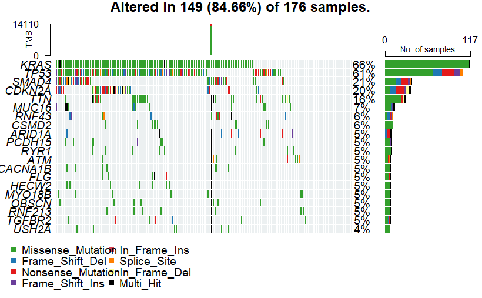

We can see the genes with more mutations.

```
oncoplot(PAAD, top = 9)
```

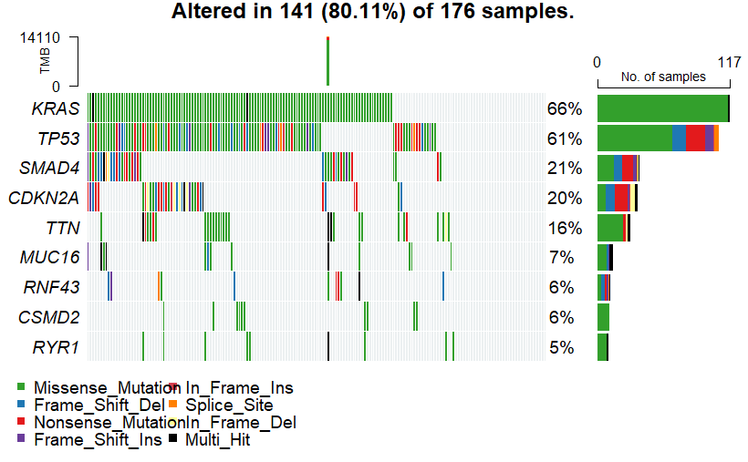

[output not shown]

SMAD4 and CDK2A appear to be mutually exclusive.

```
oncoplot(PAAD, genes = c("CDKN2A", "SMAD4"))
```

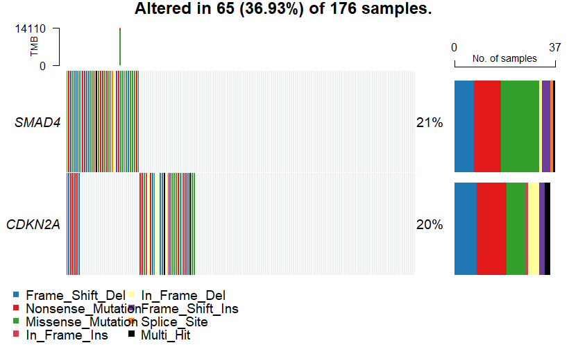

## Adding annotations

```
oncoplot(PAAD, genes = c("TP53", "KRAS", "CDKN2A", "SMAD4", "RNF43", "ARID1A"), draw_titv = TRUE)
```

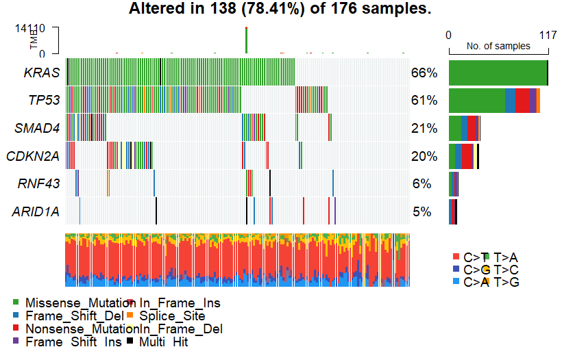

Most mutations are C>T

## Adding pathways

```
oncoplot(maf = PAAD,
         pathways = 'smgb',
         gene_mar = 5, # Changes margin width in gene names
         fontSize = 0.4, # Changes size of gene names
         topPathways = 3) # Displays 3 most affected pathways
```

```
Drawing upto top 3 mutated pathways
```

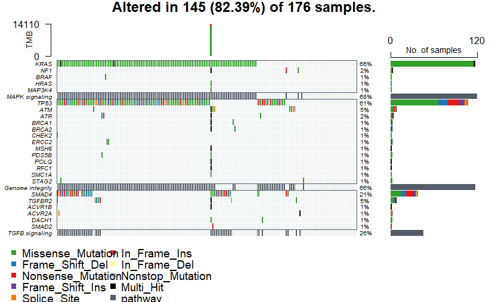

The more affected pathways are:

- MAPK signaling -> KRAS
- Genome integrity -> TP53
- TGFB signaling -> SMAD4

## Other tools

### Summary plot

```
plotmafSummary(maf = PAAD, addStat = "median", dashboard = TRUE)
```

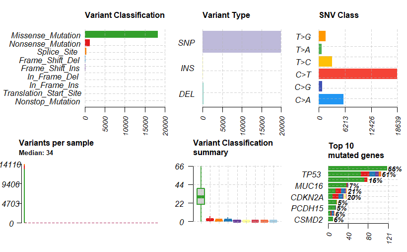

### Plot for transitions and transversions

```
PAAD_titv = titv(maf = PAAD, plot = FALSE)
plotTiTv(res = PAAD_titv)
```

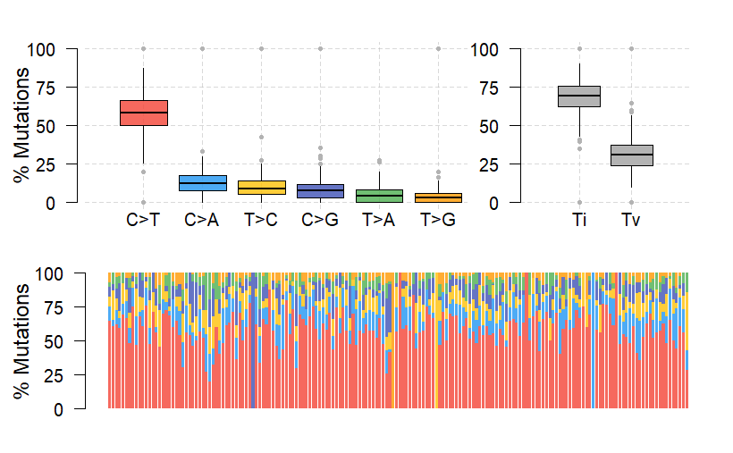

### Lollipop plot

```
lollipopPlot(maf = PAAD, gene = "TP53", showMutationRate = TRUE, labelPos = c(248, 245, 282, 273))
```

```
8 transcripts available. Use arguments refSeqID or proteinID to manually specify tx name.
```

| HGNC | refseq.ID | protein.ID | aa.length |
| --- | --- | --- | --- |
| TP53 | NM_000546 | NP_000537 | 393 |
| TP53 | NM_001126112 | NP_001119584 | 393 |
| TP53 | NM_001126113 | NP_001119585 | 346 |
| TP53 | NM_001126114 | NP_001119586 | 341 |
| TP53 | NM_001126115 | NP_001119587 | 261 |
| TP53 | NM_001126116 | NP_001119588 | 209 |
| TP53 | NM_001126117 | NP_001119589 | 214 |
| TP53 | NM_001126118 | NP_001119590 | 354 |

```
Using longer transcript NM_000546 for now.
Assuming protein change information are stored under column HGVSp_Short. Use argument AACol to override if necessary.
```

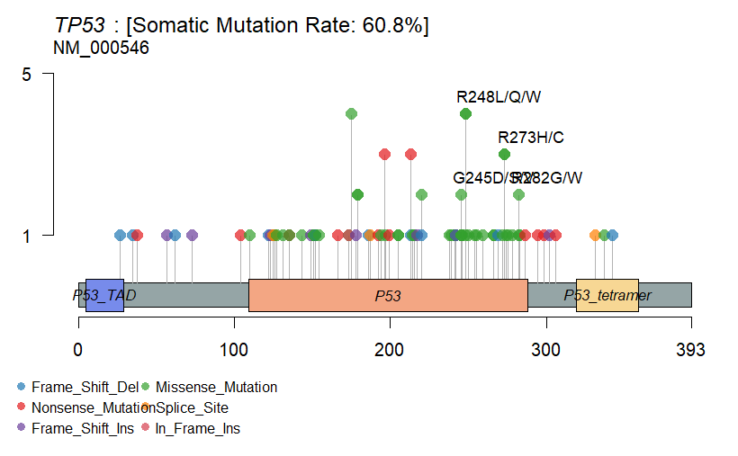

```
lollipopPlot(maf = PAAD, gene = "KRAS", showMutationRate = TRUE, labelPos = c(12, 61))
```

```
2 transcripts available. Use arguments refSeqID or proteinID to manually specify tx name.
```

| HGNC | refseq.ID | protein.ID | aa.length |
| --- | --- | --- | --- |
| KRAS | NM_004985 | NP_004976 | 188 |
| KRAS | NM_033360 | NP_203524 | 189 |

```
Using longer transcript NM_033360 for now.
Assuming protein change information are stored under column HGVSp_Short. Use argument AACol to override if necessary.
```

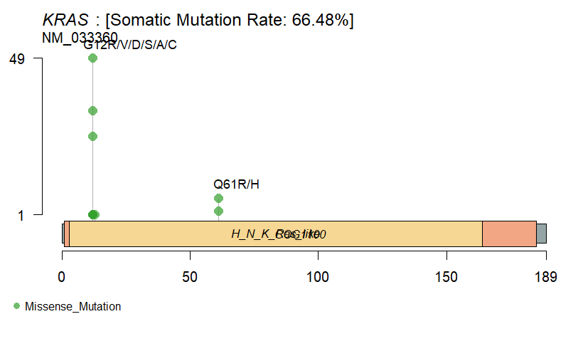

```
lollipopPlot(maf = PAAD, gene = "CDKN2A", showMutationRate = TRUE, labelPos = c(83, 97, 94))
```

```
3 transcripts available. Use arguments refSeqID or proteinID to manually specify tx name.
```

| HGNC | refseq.ID | protein.ID | aa.length |
| --- | --- | --- | --- |
| CDKN2A | NM_000077 | NP_000068 | 156 |
| CDKN2A | NM_001195132 | NP_001182061 | 167 |
| CDKN2A | NM_058195 | NP_478102 | 132 |

```
Using longer transcript NM_001195132 for now.
Assuming protein change information are stored under column HGVSp_Short. Use argument AACol to override if necessary.
```

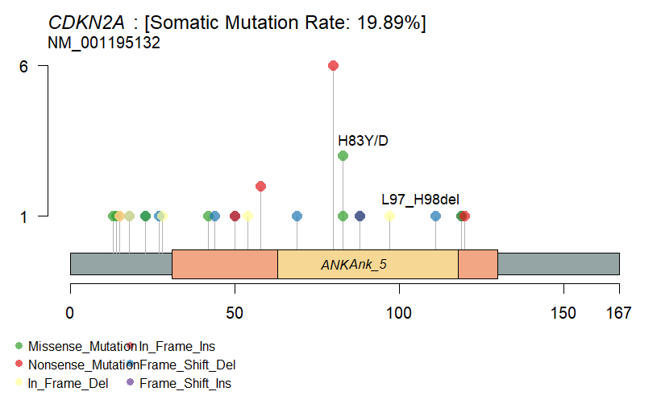

```
lollipopPlot(maf = PAAD, gene = "SMAD4", showMutationRate = TRUE)
```

```
Assuming protein change information are stored under column HGVSp_Short. Use argument AACol to override if necessary.
```

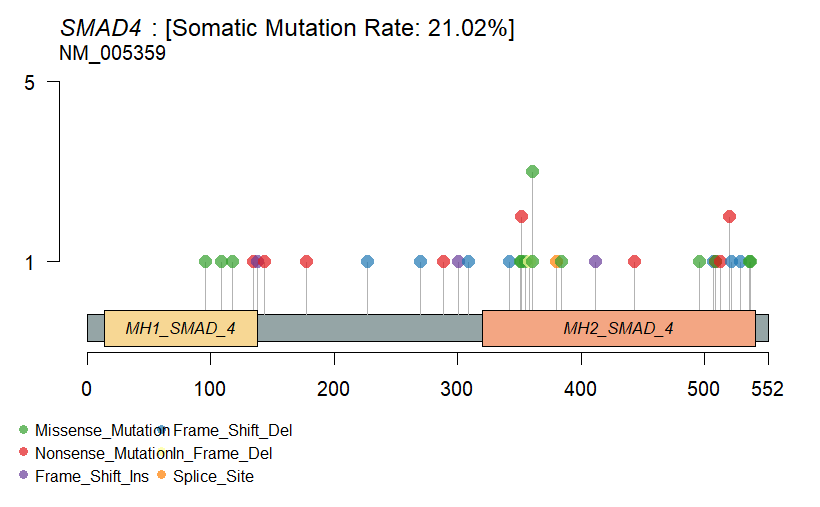

```
lollipopPlot(maf = PAAD, gene = "RNF43", showMutationRate = TRUE)
```

```
Assuming protein change information are stored under column HGVSp_Short. Use argument AACol to override if necessary.
```

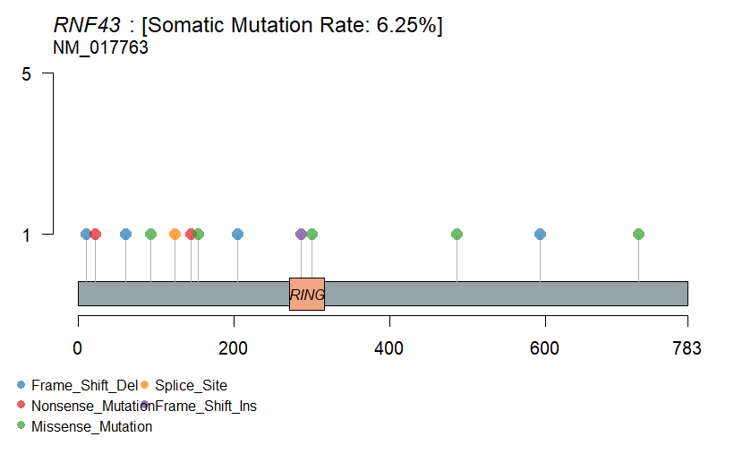

```
lollipopPlot(maf = PAAD, gene = "ARID1A", showMutationRate = TRUE)
```

```
2 transcripts available. Use arguments refSeqID or proteinID to manually specify tx name.
```

| HGNC | refseq.ID | protein.ID | aa.length |
| --- | --- | --- | --- |
| ARID1A | NM_006015 | NP_006006 | 2285 |
| ARID1A | NM_139135 | NP_624361 | 2068 |

```
Using longer transcript NM_006015 for now.
Assuming protein change information are stored under column HGVSp_Short. Use argument AACol to override if necessary.
```

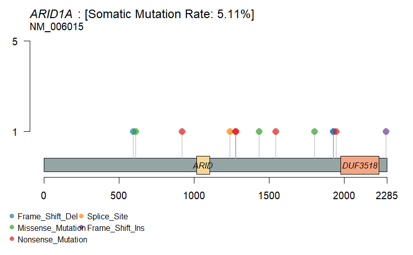